# Point Patterns Analysis for CD45 and IBA1

Data analysis notebook

Author

Affiliation

Daniel Manrique-Castano, PhD

Univerisity Laval

Published

Thursday, August 22, 2024

Keywords

CD45, IBA1, Brain injury, Point pattern analysis

# 1 Preview

This notebook performs the point pattern analysis for CD45 and IBA1 in the ipsilateral hemisphere following cerebral ischemia.

**Parent dataset:** CD45 and IBA1 stained ischemic hemispheres grouped into two treatments VEGFE and VEH.

**Working dataset**: The `Data_Raw/Vegfe_Ipsilateral_CD45_Cells.csv` and `Data_Raw/Vegfe_Ipsilateral_Iba1_Cells.csv` and data frames containing the coordinates of CD45 and IBA1+ cells obtained with CellProfiler (*1*).

# 2 Install and load required packages

Install and load all required packages. Please uncomment (delete #) the line code if installation is required. Load the installed libraries each time you start a new R session.

```r
#install.packages("devtools")
#library(devtools)

#install.packages(c("dplyr", "ggplot","plyr", "spatstat", "tidyverse"))

library(dplyr)
library(ggplot2)
library(plyr)
library(spatstat)
library(tidyverse)
```

# 3 Load and handle the datasets

We load the `Vegfe_Ipsilateral_CD45_Cells.csv` and `Vegfe_Ipsilateral_Iba1_Cells.csv` data sets. These are heavy data sets containing information about individual cells detected in the ipsilateral hemisphere.

```r
# We load the dataset in case is not present in the R environment
CD45_Cells <- read.csv(file = "Data_Raw/Vegfe_Ipsilateral_CD45_Cells.csv", header = TRUE)

Iba1_Cells <- read.csv(file = "Data_Raw/Vegfe_Ipsilateral_Iba1_Cells.csv", header = TRUE)

gt::gt(CD45_Cells[1:10,])
```

Table 1: Data set

| ImageNumber | ObjectNumber | FileName_Raw | PathName_Raw | AreaShape_Area | AreaShape_BoundingBoxArea | AreaShape_BoundingBoxMaximum_X | AreaShape_BoundingBoxMaximum_Y | AreaShape_BoundingBoxMinimum_X | AreaShape_BoundingBoxMinimum_Y | AreaShape_Center_X | AreaShape_Center_Y | AreaShape_Compactness | AreaShape_ConvexArea | AreaShape_Eccentricity | AreaShape_EquivalentDiameter | AreaShape_EulerNumber | AreaShape_Extent | AreaShape_FormFactor | AreaShape_MajorAxisLength | AreaShape_MaxFeretDiameter | AreaShape_MaximumRadius | AreaShape_MeanRadius | AreaShape_MedianRadius | AreaShape_MinFeretDiameter | AreaShape_MinorAxisLength | AreaShape_Orientation | AreaShape_Perimeter | AreaShape_Solidity | Location_Center_X | … |
| --- | --- | --- | --- | --- | --- | --- | --- | --- | --- | --- | --- | --- | --- | --- | --- | --- | --- | --- | --- | --- | --- | --- | --- | --- | --- | --- | --- | --- | --- | --- |
| 1 | 1 | A10_VEGFE_CD45.tif | D:\Research\Support_EAE\VEGFE project\Images_Raw\CD45 | 364 | 1675 | 1813 | 92 | 1746 | 67 | 1775.2995 | 79.20604 | 5.468704 | 585 | 0.9934876 | 21.52810 | 1 | 0.2173134 | 0.1828587 | 73.09363 | 69.57011 | 5.000000 | 1.812518 | 1.414214 | 9.49425 | 8.32833 | 68.84318 | 158.16043 | 0.6222222 | 1775.2995 | … |
| 1 | 2 | A10_VEGFE_CD45.tif | D:\Research\Support_EAE\VEGFE project\Images_Raw\CD45 | 455 | 846 | 1484 | 92 | 1437 | 74 | 1456.8462 | 81.86593 | 2.801756 | 578 | 0.9552662 | 24.06915 | 1 | 0.5378251 | 0.3569190 | 46.38193 | 46.87217 | 6.324555 | 2.641400 | 2.236068 | 14.64687 | 13.71733 | -76.93248 | 126.56854 | 0.7871972 | 1456.8462 | … |
| 1 | 3 | A10_VEGFE_CD45.tif | D:\Research\Support_EAE\VEGFE project\Images_Raw\CD45 | 842 | 2376 | 1437 | 120 | 1371 | 84 | 1404.3527 | 97.81235 | 4.340430 | 1197 | 0.9640295 | 32.74244 | 1 | 0.3543771 | 0.2303919 | 69.23093 | 72.06941 | 9.000000 | 3.238998 | 2.914214 | 21.67535 | 18.40124 | -67.57167 | 214.30256 | 0.7034252 | 1404.3527 | … |
| 1 | 4 | A10_VEGFE_CD45.tif | D:\Research\Support_EAE\VEGFE project\Images_Raw\CD45 | 406 | 1080 | 1884 | 122 | 1839 | 98 | 1862.2414 | 110.41379 | 2.663341 | 499 | 0.9760673 | 22.73621 | 1 | 0.3759259 | 0.3754682 | 50.50142 | 48.76474 | 5.830952 | 2.473004 | 2.236068 | 11.35299 | 10.98248 | 67.87488 | 116.56854 | 0.8136273 | 1862.2414 | … |
| 1 | 5 | A10_VEGFE_CD45.tif | D:\Research\Support_EAE\VEGFE project\Images_Raw\CD45 | 642 | 1440 | 1370 | 139 | 1325 | 107 | 1345.5296 | 118.96262 | 2.645406 | 884 | 0.8825010 | 28.59055 | 1 | 0.4458333 | 0.3780139 | 47.36663 | 49.64877 | 8.000000 | 3.135450 | 2.828427 | 24.32326 | 22.27703 | -68.03809 | 146.08936 | 0.7262443 | 1345.5296 | … |
| 1 | 6 | A10_VEGFE_CD45.tif | D:\Research\Support_EAE\VEGFE project\Images_Raw\CD45 | 340 | 609 | 842 | 138 | 813 | 117 | 825.3912 | 127.00882 | 1.963736 | 427 | 0.7916806 | 20.80628 | 1 | 0.5582923 | 0.5092335 | 27.67980 | 31.76476 | 7.211103 | 2.928119 | 2.828427 | 17.85767 | 16.91057 | 57.60994 | 91.59798 | 0.7962529 | 825.3912 | … |
| 1 | 7 | A10_VEGFE_CD45.tif | D:\Research\Support_EAE\VEGFE project\Images_Raw\CD45 | 621 | 1235 | 814 | 139 | 749 | 120 | 779.1288 | 128.97907 | 3.450320 | 869 | 0.9766886 | 28.11906 | 1 | 0.5028340 | 0.2898282 | 65.61462 | 65.51336 | 6.324555 | 2.653835 | 2.236068 | 16.74469 | 14.08490 | -79.84511 | 164.08936 | 0.7146145 | 779.1288 | … |
| 1 | 8 | A10_VEGFE_CD45.tif | D:\Research\Support_EAE\VEGFE project\Images_Raw\CD45 | 458 | 798 | 871 | 141 | 833 | 120 | 851.0590 | 129.79913 | 1.892143 | 534 | 0.9227712 | 24.14837 | 1 | 0.5739348 | 0.5285012 | 40.09492 | 39.35734 | 8.000000 | 3.143368 | 3.000000 | 15.58211 | 15.45051 | 71.12173 | 104.35534 | 0.8576779 | 851.0590 | … |
| 1 | 9 | A10_VEGFE_CD45.tif | D:\Research\Support_EAE\VEGFE project\Images_Raw\CD45 | 726 | 2088 | 758 | 154 | 686 | 125 | 720.0455 | 138.06887 | 4.035996 | 1033 | 0.9846989 | 30.40349 | 1 | 0.3477011 | 0.2477703 | 79.41221 | 74.63243 | 6.082763 | 2.599174 | 2.236068 | 16.61710 | 13.83870 | -71.92150 | 191.88835 | 0.7028074 | 720.0455 | … |
| 1 | 10 | A10_VEGFE_CD45.tif | D:\Research\Support_EAE\VEGFE project\Images_Raw\CD45 | 349 | 1015 | 1329 | 156 | 1294 | 127 | 1311.0401 | 140.92550 | 2.908813 | 485 | 0.9580279 | 21.07986 | 1 | 0.3438424 | 0.3437828 | 42.30356 | 38.89730 | 5.099020 | 2.266444 | 2.000000 | 12.80832 | 12.12738 | -58.11547 | 112.94722 | 0.7195876 | 1311.0401 | … |

We are interested in the `FileName_Raw`column containing the identification data for the images, and `Location_Center_X` and `Location_Center_Y`signaling the xy coordinates of each cell. The same apply for CD45_Cells and Iba1_Cells.

Next, we subset the dataset to select the columns of interest and give them meaningful names.

```r
### For CD45

## We subset the relevant columns (cell number)
CD45_Data <- subset(CD45_Cells, select = c("FileName_Raw", "Location_Center_X", "Location_Center_Y"))

## And extract metadata from the image name
CD45_Data  <- cbind(CD45_Data, do.call(rbind , strsplit(CD45_Data$FileName_Raw, "[_\\.]"))[,1:2])

CD45_Data <- subset(CD45_Data, select = -c(FileName_Raw))

## We Rename the relevant columns
colnames(CD45_Data) <- c("CenterX", "CenterY", "MouseID", "Treatment")

## We set the factors
CD45_Data$Treatment <- factor(CD45_Data$Treatment, levels = c("VEH", "VEGFE"))

write.csv(CD45_Data, "Data_Processed/Widefield_Ipsilateral_CD45.csv", row.names = FALSE)


### For Iba1

## We subset the relevant columns (cell number)
Iba1_Data <- subset(Iba1_Cells, select = c("FileName_Raw", "Location_Center_X", "Location_Center_Y"))

## And extract metadata from the image name
Iba1_Data  <- cbind(Iba1_Data, do.call(rbind , strsplit(Iba1_Data$FileName_Raw, "[_\\.]"))[,1:2])

Iba1_Data <- subset(Iba1_Data, select = -c(FileName_Raw))

## We Rename the relevant columns
colnames(Iba1_Data) <- c("CenterX", "CenterY", "MouseID", "Treatment")

## We set the factors
Iba1_Data$Treatment <- factor(Iba1_Data$Treatment, levels = c("VEH", "VEGFE"))

write.csv(Iba1_Data, "Data_Processed/Widefield_Ipsilateral_Iba1.csv", row.names = FALSE)
```

With the data handled, we create point patterns to perform point pattern analysis (PPA). With this approach, we can estimate the spatial intensity of colocalized cells and their distribution relative to covariates.

# 4 Generate and handle point patterns

We use functions from the `spatstat` package to create point patterns based on the coordinates of individual cells. The point patterns are then stored in a hyperframe and can be loaded into R as an R-object.

## 4.1 For CD45

```r
# Initialize the hyperframe as NULL at the start
Result_Hyperframe <- NULL

# Adjusted add_to_hyperframe function to dynamically build the hyperframe
add_to_hyperframe <- function(...) {
  if (is.null(Result_Hyperframe)) {
    Result_Hyperframe <<- hyperframe(...)
  } else {
    Result_Hyperframe <<- tryCatch({
      rbind(Result_Hyperframe, hyperframe(...))
    }, error = function(e) {
      cat("Error in rbind: ", e$message, "\n")
    })
  }
}

# Adjusted function to create point patterns
create_point_pattern <- function(Data_Subset) {
  xlim <- range(Data_Subset$CenterX)
  ylim <- range(Data_Subset$CenterY)

  Cells_PPP <- spatstat.geom::ppp(x = Data_Subset$CenterX, y = Data_Subset$CenterY, xrange = xlim, yrange = ylim)
  unitname(Cells_PPP) <- list("mm", "mm", 497.078/5872)
  Cells_PPP <- spatstat.geom::rescale(Cells_PPP)

  return(Cells_PPP)
}

# Iterate over unique MouseIDs
mouse_ids <- unique(CD45_Data$MouseID)

for (mouse_id in mouse_ids) {
  Subset_CD45 <- CD45_Data[CD45_Data$MouseID == mouse_id, ]

  if(nrow(Subset_CD45) > 0 && nrow(Subset_CD45) > 0) {
    CD45_PPP <- create_point_pattern(Subset_CD45)

    # Set the observation window
    Window(CD45_PPP) <- convexhull(CD45_PPP)

    Treatment_value <- unique(Subset_CD45$Treatment)[1]

    add_to_hyperframe(CD45 = CD45_PPP, ID = as.character(mouse_id), Treatment = as.factor(Treatment_value), stringsAsFactors = TRUE)
  } else {
    message(sprintf("Skipping MouseID %s due to insufficient data.\n", mouse_id))
  }
}

# Save the Result_Hyperframe
Result_Hyperframe$Treatment <- factor(Result_Hyperframe$Treatment, levels = c("VEH", "VEGFE"))

saveRDS(Result_Hyperframe, "PointPatterns/Widefield_Ipsilateral_CD45_PPP.rds")
```

## 4.2 For IBA1

```r
# Initialize the hyperframe as NULL at the start
Result_Hyperframe <- NULL

# Adjusted add_to_hyperframe function to dynamically build the hyperframe
add_to_hyperframe <- function(...) {
  if (is.null(Result_Hyperframe)) {
    Result_Hyperframe <<- hyperframe(...)
  } else {
    Result_Hyperframe <<- tryCatch({
      rbind(Result_Hyperframe, hyperframe(...))
    }, error = function(e) {
      cat("Error in rbind: ", e$message, "\n")
    })
  }
}

# Adjusted function to create point patterns
create_point_pattern <- function(Data_Subset) {
  xlim <- range(Data_Subset$CenterX)
  ylim <- range(Data_Subset$CenterY)

  Cells_PPP <- spatstat.geom::ppp(x = Data_Subset$CenterX, y = Data_Subset$CenterY, xrange = xlim, yrange = ylim)
  unitname(Cells_PPP) <- list("mm", "mm", 497.078/5872)
  Cells_PPP <- spatstat.geom::rescale(Cells_PPP)

  return(Cells_PPP)
}

# Iterate over unique MouseIDs
mouse_ids <- unique(Iba1_Data$MouseID)

for (mouse_id in mouse_ids) {
  Subset_Iba1 <- Iba1_Data[Iba1_Data$MouseID == mouse_id, ]

  if(nrow(Subset_Iba1) > 0 && nrow(Subset_Iba1) > 0) {
    Iba1_PPP <- create_point_pattern(Subset_Iba1)

    # Set the observation window
    Window(Iba1_PPP) <- convexhull(Iba1_PPP)

    Treatment_value <- unique(Subset_Iba1$Treatment)[1]

    add_to_hyperframe(Iba1 = Iba1_PPP, ID = as.character(mouse_id), Treatment = as.factor(Treatment_value), stringsAsFactors = TRUE)
  } else {
    message(sprintf("Skipping MouseID %s due to insufficient data.\n", mouse_id))
  }
}

# Save the Result_Hyperframe
Result_Hyperframe$Treatment <- factor(Result_Hyperframe$Treatment, levels = c("VEH", "VEGFE"))

saveRDS(Result_Hyperframe, "PointPatterns/Widefield_Ipsilateral_Iba1_PPP.rds")
```

The point patterns are stored as an R-object. In the next chunk, we load the point patterns and add density kernels.

# 5 Calculate density kernels

```r
# Load the point patterns
PointPatterns_CD45 <- readRDS("PointPatterns/Widefield_Ipsilateral_CD45_PPP.rds")

PointPatterns_Iba1 <- readRDS("PointPatterns/Widefield_Ipsilateral_Iba1_PPP.rds")

# Add density kernels to the hyperframe
PointPatterns_CD45$CD45_Density <- with (PointPatterns_CD45, density(CD45, sigma = 10))
PointPatterns_Iba1$Iba1_Density <- with (PointPatterns_Iba1, density(Iba1, sigma = 10))
```

## 5.1 Plot density kernels

We plot some examples of the density kernels. Please note that the coordinates are y-fliped for unknown reason to us.

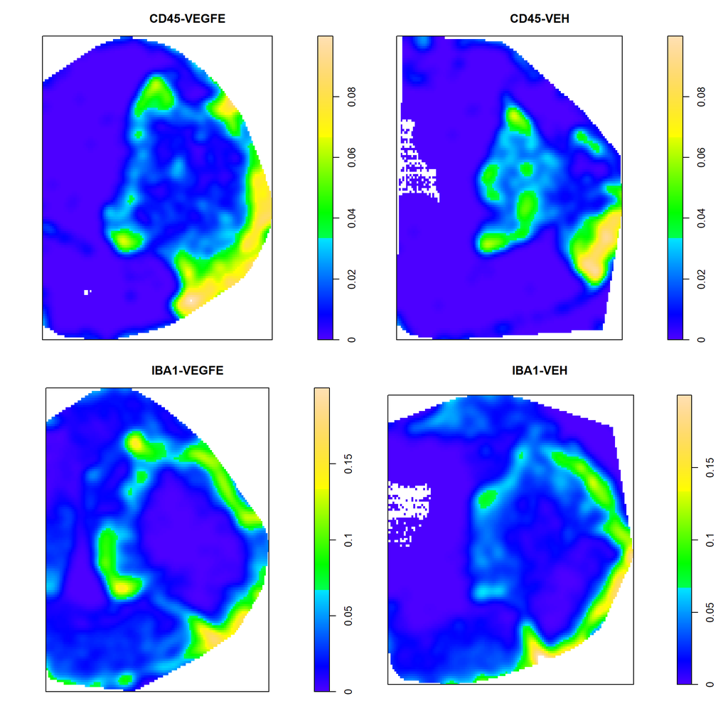

Figure 1: Example density kernels for CD45 and Iba1

```r
CD45_Colmap <- colourmap(topo.colors(256), range = c(0, 0.1))
Iba1_Colmap <- colourmap(topo.colors(256), range = c(0, 0.2))

par(mfrow = c(2,2), mar=c(1,1,1,1), oma=c(1,1,1,1))

## For CD45

plot(PointPatterns_CD45$CD45_Density$`1`, col = CD45_Colmap, main = "CD45-VEGFE")

plot(PointPatterns_CD45$CD45_Density$`12`, col = CD45_Colmap, main = "CD45-VEH")

## For Iba1

plot(PointPatterns_Iba1$Iba1_Density$`11`, col = Iba1_Colmap, main = "IBA1-VEGFE")

plot(PointPatterns_Iba1$Iba1_Density$`13`, col = Iba1_Colmap, main = "IBA1-VEH")
```

Figure 1 shows example plots per treatment.

# 6 Modeling the relative distribution

Here, we model the relative distribution of CD45 and IBA1 cells relative to the x coordinates of the brain.

First, we subset the point patterns

```r
PointPatterns_CD45_VEGFE <- subset(PointPatterns_CD45, Treatment=="VEGFE", select = 1:4)
PointPatterns_CD45_VEH   <- subset(PointPatterns_CD45, Treatment=="VEH", select = 1:4)

PointPatterns_Iba1_VEGFE <- subset(PointPatterns_Iba1, Treatment=="VEGFE", select = 1:4)
PointPatterns_Iba1_VEH   <- subset(PointPatterns_Iba1, Treatment=="VEH", select = 1:4)
```

Now, we calculate the relative distribution of CD45 and IBA1 conditional on the x coordinates.

```r
# For CD45
CD45_VEGFE <- with(PointPatterns_CD45_VEGFE, spatstat.explore::rhohat.ppp(CD45, "x", do.CI = FALSE))
CD45_VEGFE <- pool(CD45_VEGFE)

CD45_VEH<- with(PointPatterns_CD45_VEH, spatstat.explore::rhohat.ppp(CD45, "x", do.CI = FALSE))
CD45_VEH <- pool(CD45_VEH)

# For Iba1
Iba1_VEGFE <- with(PointPatterns_Iba1_VEGFE, spatstat.explore::rhohat.ppp(Iba1, "x", do.CI = FALSE))
Iba1_VEGFE <- pool(Iba1_VEGFE)

Iba1_VEH<- with(PointPatterns_Iba1_VEH, spatstat.explore::rhohat.ppp(Iba1, "x", do.CI = FALSE))
Iba1_VEH <- pool(Iba1_VEH)
```

Finally, we plot the `rhohat`.

## 6.1 Plot the rhohat

Now, we plot the calculated relative distribution.

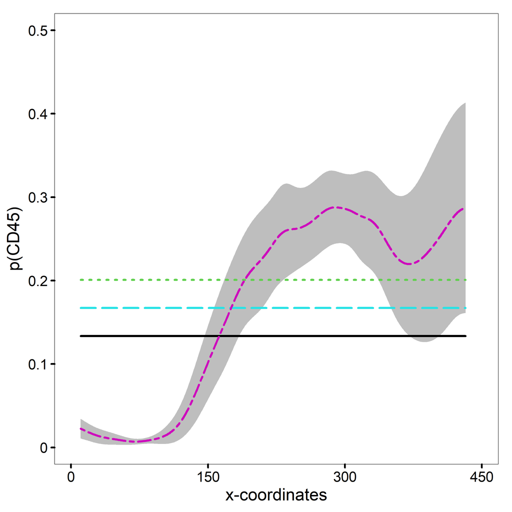

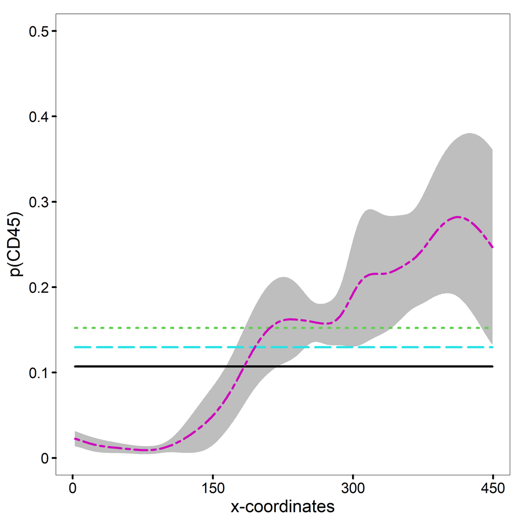

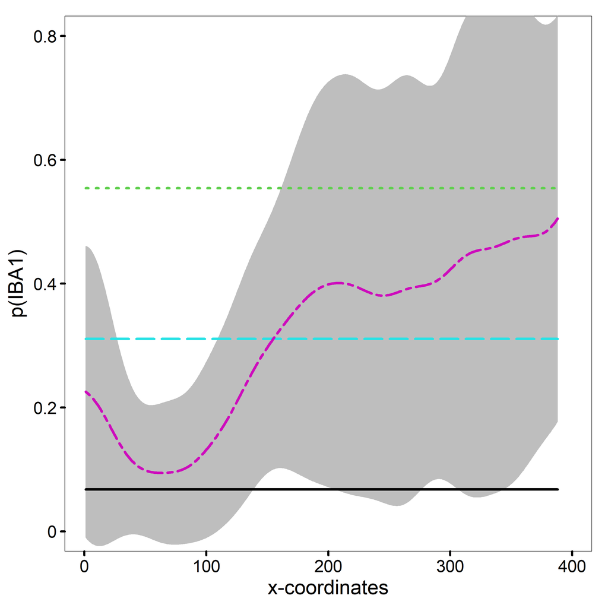

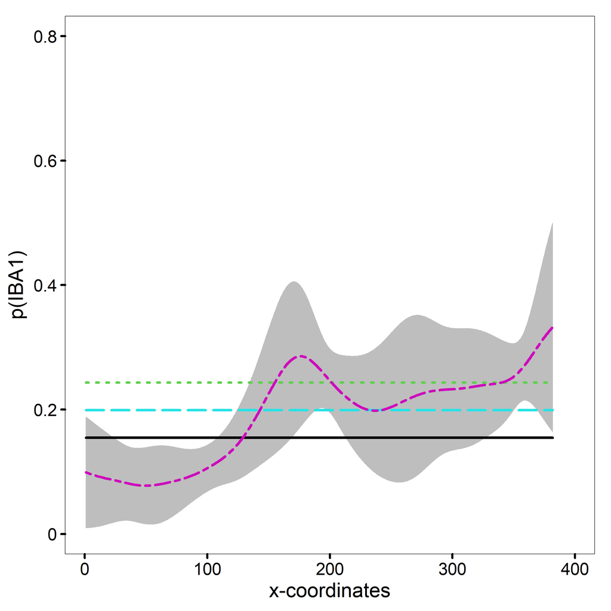

```r
## CD45 VEGFE

# png("Plots/Widefield_Ipsilateral_CD45_VEGFE.png", width = 500, height = 400)
par(mar=c(7,8,2,2))
par(las=1)
plot(CD45_VEGFE,
     shade = c("lorho", "hirho"),
     main=NULL,
     las=1,
     legendargs=list(xpd=TRUE),
     xlim =c(0, 450),
     ylim =c(0, 0.05),
     lwd = 6,
     legend=FALSE,
     xlab = "",
     ylab = "",
     xaxt = "n",
     yaxt = "n")

axis(1, at = seq(0, 500, 150), labels = c("0",  "150", "300", "450"), cex.axis=2.5, padj = 0.5, lwd.ticks = 5)

axis(2, at = seq(0, 0.06, 0.01), labels = c("0",  "0.1", "0.2", "0.3", "0.4", "0.5", "0.6"), cex.axis=2.5, padj = 0.5, lwd.ticks = 5)

title(xlab = "x-coordinates", mgp = c(4.5, 1, 0), cex.lab = 3)
title(ylab = "p(CD45)", mgp = c(5, 1, 0), cex.lab = 3)
#dev.off()


## CD45 VEH

#png("Plots/Widefield_Ipsilateral_CD45_VEH.png", width = 500, height = 400)
par(mar=c(7,8,2,2))
par(las=1)
plot(CD45_VEH,
     shade = c("lorho", "hirho"),
     main=NULL,
     las=1,
     legendargs=list(xpd=TRUE),
     xlim =c(0, 450),
     ylim =c(0, 0.05),
     lwd = 6,
     legend=FALSE,
     xlab = "",
     ylab = "",
     xaxt = "n",
     yaxt = "n")

axis(1, at = seq(0, 500, 150), labels = c("0",  "150", "300", "450"), cex.axis=2.5, padj = 0.5, lwd.ticks = 5)

axis(2, at = seq(0, 0.06, 0.01), labels = c("0",  "0.1", "0.2", "0.3", "0.4", "0.5", "0.6"), cex.axis=2.5, padj = 0.5, lwd.ticks = 5)

title(xlab = "x-coordinates", mgp = c(4.5, 1, 0), cex.lab = 3)
title(ylab = "p(CD45)", mgp = c(5, 1, 0), cex.lab = 3)
#dev.off()


## Iba1 VEGFE

#png("Plots/Widefield_Ipsilateral_Iba1_VEGFE.png", width = 500, height = 400)
par(mar=c(7,8,2,2))
par(las=1)
plot(Iba1_VEGFE,
     shade = c("lorho", "hirho"),
     main=NULL,
     las=1,
     legendargs=list(xpd=TRUE),
     xlim =c(0, 400),
     ylim =c(0, 0.08),
     lwd = 6,
     legend=FALSE,
     xlab = "",
     ylab = "",
     xaxt = "n",
     yaxt = "n")

axis(1, at = seq(0, 400, 100), labels = c("0",  "100", "200", "300", "400"), cex.axis=2.5, padj = 0.5, lwd.ticks = 5)

axis(2, at = seq(0, 0.08, 0.02), labels = c("0",  "0.2", "0.4", "0.6", "0.8"), cex.axis=2.5, padj = 0.5, lwd.ticks = 5)

title(xlab = "x-coordinates", mgp = c(4.5, 1, 0), cex.lab = 3)
title(ylab = "p(IBA1)", mgp = c(5, 1, 0), cex.lab = 3)
#dev.off()


## Iba1 VEH

#png("Plots/Widefield_Ipsilateral_Iba1_VEH.png", width = 500, height = 400)
par(mar=c(7,8,2,2))
par(las=1)
plot(Iba1_VEH,
     shade = c("lorho", "hirho"),
     main=NULL,
     las=1,
     legendargs=list(xpd=TRUE),
     xlim =c(0, 400),
     ylim =c(0, 0.08),
     lwd = 6,
     legend=FALSE,
     xlab = "",
     ylab = "",
     xaxt = "n",
     yaxt = "n")

axis(1, at = seq(0, 400, 100), labels = c("0",  "100", "200", "300", "400"), cex.axis=2.5, padj = 0.5, lwd.ticks = 5)

axis(2, at = seq(0, 0.08, 0.02), labels = c("0",  "0.2", "0.4", "0.6", "0.8"), cex.axis=2.5, padj = 0.5, lwd.ticks = 5)

title(xlab = "x-coordinates", mgp = c(4.5, 1, 0), cex.lab = 3)
title(ylab = "p(IBA1)", mgp = c(5, 1, 0), cex.lab = 3)
#dev.off()
```

# 7 Modeling point pattern process

Now, we use the `mppm` function from `spatstat` (*2*)to fit a **log-linear model** for replicated point patterns. This model allow us to quantify CD45 and IBA1 allocation changes conditional on the x coordinates in the ischemic hemisphere.

## 7.1 Fit the mppm model

We fit the model using the `mppm` function for replicated point patterns:

```r
CD45_mppm <- mppm(CD45 ~ x, random = ~  x|Treatment, data = PointPatterns_CD45)
```

```
iteration 1
iteration 2
iteration 3
```

```r
summary(CD45_mppm )
```

```
Point process model fitted to 17 point patterns
Call: mppm(CD45 ~ x, random = ~x | Treatment, data = PointPatterns_CD45)
Log trend formula: ~x

Fixed effects:
 (Intercept)            x
-5.511006252  0.004844299
Random effects:
      (Intercept)             x
VEH    -0.2914383  0.0004958336
VEGFE   0.2914383 -0.0004958336
All fitted coefficients:
 (Intercept)            x
-5.511006252  0.004844299

Random effects summary:
Random effects:
 Formula: ~x | Treatment
 Structure: General positive-definite, Log-Cholesky parametrization
            StdDev       Corr
(Intercept) 0.2150826537 (Intr)
x           0.0003659613 -1
Residual    1.0000000000

Variance function:
 Structure: fixed weights
 Formula: ~invwt

Interaction for all patterns:
Poisson process


--- Gory details: ---
Combined data frame has 305540 rows
Linear mixed-effects model fit by maximum likelihood
  Data: moadf
  Subset: glmmsubset
      AIC     BIC    logLik
  1585344 1585408 -792666.2

```

[output cut: 10 more lines]

```
 Formula: ~invwt
Fixed effects:  .mpl.Y ~ x
                Value  Std.Error     DF   t-value p-value
(Intercept) -5.511006 0.20692255 305537 -26.63318       0
x            0.004844 0.00035395 305537  13.68658       0
 Correlation:
  (Intr)
x -0.998

Standardized Within-Group Residuals:
       Min         Q1        Med         Q3        Max
-0.8690399 -0.3754774 -0.2777569 -0.1968619 33.9993358

Number of Observations: 305540
Number of Groups: 2
```

```r
Iba1_mppm <- mppm(Iba1 ~ x, random = ~  x|Treatment, data = PointPatterns_Iba1)
```

```
iteration 1
iteration 2
iteration 3
```

```r
summary(Iba1_mppm )
```

```
Point process model fitted to 11 point patterns
Call: mppm(Iba1 ~ x, random = ~x | Treatment, data = PointPatterns_Iba1)
Log trend formula: ~x

Fixed effects:
 (Intercept)            x
-4.470822292  0.003628417
Random effects:
      (Intercept)             x
VEH    -0.2314295  5.419601e-09
VEGFE   0.2314295 -5.419601e-09
All fitted coefficients:
 (Intercept)            x
-4.470822292  0.003628417

Random effects summary:
Random effects:
 Formula: ~x | Treatment
 Structure: General positive-definite, Log-Cholesky parametrization
            StdDev       Corr
(Intercept) 1.310392e-01 (Intr)
x           1.192496e-07 -0.03
Residual    1.000000e+00

Variance function:
 Structure: fixed weights
 Formula: ~invwt

Interaction for all patterns:
Poisson process


--- Gory details: ---
Combined data frame has 256970 rows
Linear mixed-effects model fit by maximum likelihood
  Data: moadf
  Subset: glmmsubset
      AIC     BIC    logLik
  1512001 1512064 -755994.6

```

[output cut: 10 more lines]

```
 Formula: ~invwt
Fixed effects:  .mpl.Y ~ x
                Value  Std.Error     DF   t-value p-value
(Intercept) -4.470822 0.16487876 256967 -27.11582       0
x            0.003628 0.00006722 256967  53.97549       0
 Correlation:
  (Intr)
x -0.097

Standardized Within-Group Residuals:
       Min         Q1        Med         Q3        Max
-0.7024259 -0.3070304 -0.1991074 -0.1125006 26.5265632

Number of Observations: 256970
Number of Groups: 2
```

# 8 References

1.

D. R. Stirling, M. J. Swain-Bowden, A. M. Lucas, A. E. Carpenter, B. A. Cimini, A. Goodman, CellProfiler 4: improvements in speed, utility and usability. *BMC Bioinformatics*. **22** (2021), doi:10.1186/s12859-021-04344-9.

2.

A. Baddeley, E. Rubak, R. Turner, Spatial point patterns: Methodology and applications with r (2015) (available at https://www.routledge.com/Spatial-Point-Patterns-Methodology-and-Applications-with-R/Baddeley-Rubak-Turner/p/book/9781482210200/).